# Bivariate maps with ggplot2 and sf

Timo Grossenbacher and Angelo Zehr

For this blog post, I worked together with my colleague [Angelo Zehr](https://twitter.com/angelozehr) who recently published a [nice bivariate thematic map](https://www.srf.ch/news/schweiz/interaktive-karte-so-ungleich-ist-das-einkommen-in-der-schweiz-verteilt) comparing income (in-)equality and average income in Switzerland. We took this opportunity to give a major update of my post on [thematic maps with ggplot2](https://timogrossenbacher.ch/2016/12/beautiful-thematic-maps-with-ggplot2-only/) which is more than two years old, but still attracts hundreds of visits each week.

**What is different from said post?**

- With the `sf` packacke and its integration into `ggplot2` through the `geom_sf()` function, it is nowadays even easier to quickly create thematic maps.
- This post does not only show how to produce a simple univariate choropleth (another word for a thematic map where the (fill) color is used as the main visual variable) but also how to combine two variables into a bivariate color scale.
- It introduces *a suitable legend* for bivariate color scales using `geom_tile()`.
- It shows how to add *annotations* that explain spatial patterns.

## Outline

This tutorial is structured as follows:

- Read in the thematic data and geodata and join them.
- Define a general map theme.
- Create a univariate thematic map showing the average income. This largely draws from [the previous post](https://timogrossenbacher.ch/2016/12/beautiful-thematic-maps-with-ggplot2-only) and involves techniques for custom color classes and advanced aesthetics. *People who merely want an update regarding `sf` and how it interacts with `ggplot2` can just read this section*.
- Create a bivariate thematic map showing average income and income (in-)equality at the same time. In this process, a custom legend is created and added to the plot, and annotations explaining different spatial patterns are added as well.
- Oh, and lakes and cantonal borders (cantons = Swiss provinces) are now added as well.

Let’s go!

## Reproducibility

As always, you can reproduce, reuse and remix everything you find here, just go to [this repository](https://github.com/grssnbchr/bivariate-maps-ggplot2-sf) and clone it. All the needed input files are in the `input` folder, and the main file to execute is `index.Rmd`. Right now, knitting it produces an `index.md` that I use for my blog post on timogrossenbacher.ch, but you can adapt the script to produce an HTML file, too. The PNGs produced herein are saved to `wp-content/uploads/2019/04` so I can display them directly in my blog, but of course you can also adjust this.

### GitHub

The code for the herein described process can also be freely downloaded from https://github.com/grssnbchr/bivariate-maps-ggplot2-sf.

### License

**CC-BY-SA**

### Version information

This report was generated on 2024-07-20 22:36:08.540795. R version: 4.3.1 on x86_64-w64-mingw32. For this report, CRAN packages as of 2024-07-20 22:34:47.051164 were used.

## Preparations

### Clear workspace and install necessary packages

What follows from here until the section **Data Sources** is just the usual routine: Detach all packages, remove all variables in the global environment, etc, and then load the packages from the MRAN server (a snapshot from March 1st, 2019). With this, we ensure [reproducibility and cross-device compatibility](https://timogrossenbacher.ch/2017/07/a-truly-reproducible-r-workflow/). We use Timo’s [freely available template](https://github.com/grssnbchr/rddj-template) for this, with some adaptions detailed under **Reproducibility**.

Function `detach_all_packages`: This function is intended to unload (detach) all packages currently loaded in the R session, except for the basic system packages. This can be useful to clean up the working environment and avoid conflicts between packages or simply to free memory.

The `csf()` function is intended to determine the directory of the file currently running in R, whether it is run from the command line, sourced in RStudio, run from the R console, or running a selection of code in RStudio. This function is useful for obtaining the path to the current script file regardless of how it is running.

### Define packages

For this project, we use the usual suspects, i.e. `tidyverse` packages including `ggplot2` for plotting, `sf` for geodata processing and `raster` for working with (spatial) raster data, i.e. the relief. Also, the `viridis` package imports the beautiful Viridis color scale we use for the univariate map. Lastly, `cowplot` is used to combine the bivariate map and its custom legend.

```r
# from https://mran.revolutionanalytics.com/web/packages/checkpoint/vignettes/using-checkpoint-with-knitr.html
# if you don't need a package, remove it from here (commenting is probably not sufficient)
cat("
    library(rstudioapi)
    library(tidyverse) # ggplot2, dplyr, tidyr, readr, purrr, tibble
    library(magrittr) # pipes
    library(lintr) # code linting
    library(sf) # spatial data handling
    library(raster) # raster handling (needed for relief)
    library(viridis) # viridis color scale
    library(cowplot) # stack ggplots
    library(rmarkdown)",
    file = "manifest.R")
```

### Install packages

If you’re interested in what the following does, we recommend going through the explanations for [rddj-template](https://github.com/grssnbchr/rddj-template#more-about-checkpoint).

```r
# if checkpoint is not yet installed, install it (for people using this
# system for the first time)
if (!require(checkpoint)) {
  if (!require(devtools)) {
    install.packages("devtools", repos = "http://cran.us.r-project.org")
    require(devtools)
  }
  devtools::install_github("RevolutionAnalytics/checkpoint",
                           #ref = "v0.3.2", # could be adapted later,
                           # as of now (beginning of July 2017
                           # this is the current release on CRAN)
                           repos = "http://cran.us.r-project.org")
  require(checkpoint)
}
```

```
checkpoint: Part of the Reproducible R Toolkit from Microsoft
https://mran.microsoft.com/documents/rro/reproducibility/
```

```r
# nolint start
if (!dir.exists("~/.checkpoint")) {
  dir.create("~/.checkpoint")
}
# nolint end
# install packages for the specified CRAN snapshot date
#checkpoint(snapshot_date = package_date,
 #          project = path_to_wd,
  #         verbose = T,
   #        scanForPackages = T,
    #       use.knitr = F,
     #      R.version = R_version)
#rm(package_date)
```

### Load packages

```r
source("manifest.R")
```

```r
#unlink("manifest.R") #to delete the manifest.R file after the libraries have been loaded.
sessionInfo()
```

## Data Sources

### Thematic Data

Here the thematic data to be visualized is loaded. It is contained in a CSV consisting of columns:

- `municipality` (municipality name, not used),
- `bfs_id` (ID to match with geodata),
- `mean` (average income in the municipality)
- `gini` (the Gini index for income (in-)equality)

The data provider in this case is the Swiss Federal Tax Administration (FTA), where the original data (as an Excel) can be downloaded from here. The columns used were `mean_reinka` and `gini_reinka` for `mean` and `gini` (in the “Gemeinden - Communes” tab), respectively. See the first tabs in the Excel for a short explanation. Find additional explanations on [the FTA website (German)](https://www.estv.admin.ch/estv/de/home/allgemein/steuerstatistiken/fachinformationen/steuerstatistiken/direkte-bundessteuer.html), especially in [this PDF](https://www.estv.admin.ch/dam/estv/de/dokumente/allgemein/Dokumentation/Zahlen_fakten/Steuerstatistiken/direkte_bundessteuer/np_statistische_kennzahlen_ohne/Einleitung.pdf.download.pdf/1-Einleitung_NP_d.pdf).

We used the year 2015 as it is the youngest in the available time series.

```r
data <- read_csv("input/data.csv")
```

### Geodata

Various geodata from the Swiss Federal Statistical Office (FSO) and the Swiss Federal Office of Topography (swisstopo) depicting Swiss borders as of 2015 are used herein.

```r
# read cantonal borders
canton_geo <- read_sf("input/g2k15.shp")

# read country borders
country_geo <- read_sf("input/g2l15.shp")

# read lakes
lake_geo <- read_sf("input/g2s15.shp")

# read productive area (2324 municipalities)
municipality_prod_geo <- read_sf("input/gde-1-1-15.shp")

# read in raster of relief
relief <- raster("input/02-relief-ascii.asc") %>%
  # hide relief outside of Switzerland by masking with country borders
          mask(country_geo) %>%
          as("SpatialPixelsDataFrame") %>%
          as.data.frame() %>%
          rename(value = `X02.relief.ascii`)

# clean up
#rm(country_geo)
```

### Join Geodata with Thematic Data

In the following chunk, the municipality geodata is extended (joined) with the thematic data over each municipality’s unique identifier, so we end up with a data frame consisting of the thematic data as well as the geometries. Note that the class of this resulting object is still `sf` as well as `data.frame`.

```r
municipality_prod_geo %<>%
   left_join(data, by = c("BFS_ID" = "bfs_id"))

class(municipality_prod_geo)
```

```
[1] "sf"         "tbl_df"     "tbl"        "data.frame"
```

## Define a Map Theme

We first define a unique theme for the map, e.g. remove all axes, add a subtle grid (that you might not be able to see on a bright screen) etc. We mostly copied this from [another of Timo’s blog posts](https://timogrossenbacher.ch/2018/03/categorical-spatial-interpolation-with-r/).

```r
theme_map <- function(...) {
  theme_minimal() +
  theme(
    text = element_text(family = default_font_family,
                        color = default_font_color),
    # remove all axes
    axis.line = element_blank(),
    axis.text.x = element_blank(),
    axis.text.y = element_blank(),
    axis.ticks = element_blank(),
    # add a subtle grid
    panel.grid.major = element_line(color = "#dbdbd9", size = 0.2),
    panel.grid.minor = element_blank(),
    # background colors
    plot.background = element_rect(fill = default_background_color,
                                   color = NA),
    panel.background = element_rect(fill = default_background_color,
                                    color = NA),
    legend.background = element_rect(fill = default_background_color,
                                     color = NA),
    # borders and margins
    plot.margin = unit(c(.5, .5, .2, .5), "cm"),
    panel.border = element_blank(),
    panel.spacing = unit(c(-.1, 0.2, .2, 0.2), "cm"),
    # titles
    legend.title = element_text(size = 11),
    legend.text = element_text(size = 9, hjust = 0,
                               color = default_font_color),
    plot.title = element_text(size = 15, hjust = 0.5,
                              color = default_font_color),
    plot.subtitle = element_text(size = 10, hjust = 0.5,
                                 color = default_font_color,
                                 margin = margin(b = -0.1,
                                                 t = -0.1,
                                                 l = 2,
                                                 unit = "cm"),
                                 debug = F),
    # captions
    plot.caption = element_text(size = 7,
                                hjust = .5,
                                margin = margin(t = 0.2,
                                                b = 0,
                                                unit = "cm"),
                                color = "#939184"),
    ...
  )
}
```

## Create a Univariate Choropleth

First, let’s create a standard (univariate) choropleth map based on the average income alone, i.e. the `mean` variable.

Without going into much detail, this is basically the same process as in the 2016 blog post, detailed in the [respective section](https://timogrossenbacher.ch/2016/12/beautiful-thematic-maps-with-ggplot2-only/#discrete-classes-with-quantile-scale), just using `sf` instead of `sp`.

1. We first calculate quantiles from the average income to form 6 different classes of average income (quantiles are used so each color class contains approximately the same amount of municipalities). From this, we generate a new variable `mean_quantiles` which is actually visualized on the map. We also generate custom labels for the classes.
2. We generate and draw the `ggplot2` object as follows:
- Specify the main data source.
- Add the relief through a call to `geom_raster()`.
- Add a truncated alpha scale for the relief, as the “fill” aesthetic is already taken (refer to [this section](https://timogrossenbacher.ch/2016/12/beautiful-thematic-maps-with-ggplot2-only/#relief) for an explanation).
- Use `geom_sf()` without an additional data argument to specify the main fill aesthetic (the visual variable showing the average income per municipality) and to visualize municipal borders.
- Add the Viridis color scale for that fill aesthetic.
- Use two more `geom_sf()` calls to add cantonal borders and lakes stemming from the `canton_geo` and `lake_geo` datasets, respectively.
- Add titles and subtitles.
- Specify our previously defined map theme.

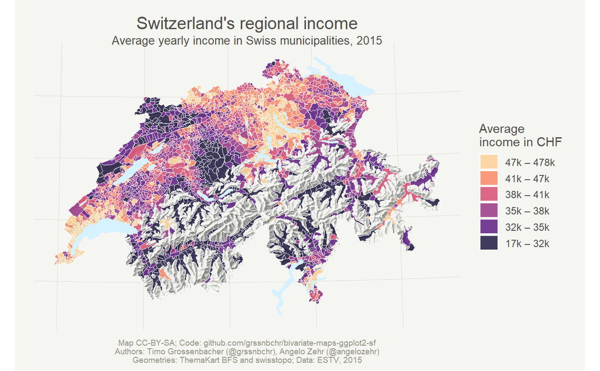

```r
# define number of classes
no_classes <- 6

# extract quantiles
quantiles <- municipality_prod_geo %>%
              pull(mean) %>%
               quantile(probs = seq(0, 1, length.out = no_classes + 1)) %>%
                 as.vector() # to remove names of quantiles, so idx below is numeric

# here we create custom labels
labels <- imap_chr(quantiles, function(., idx){
            return(paste0(round(quantiles[idx] / 1000, 0),
                                       "k",
                                       " – ",
                                       round(quantiles[idx + 1] / 1000, 0),
                                       "k"))
})

# we need to remove the last label
# because that would be something like "478k - NA"
labels <- labels[1:length(labels) - 1]

# here we actually create a new
# variable on the dataset with the quantiles
municipality_prod_geo %<>%
  mutate(mean_quantiles = cut(mean,
                              breaks = quantiles,
                              labels = labels,
                              include.lowest = T))

ggplot(# define main data source
       data = municipality_prod_geo
       ) +
 # first: draw the relief
 geom_raster(data = relief,
             inherit.aes = FALSE,
             aes(x = x,
                 y = y,
                 alpha = value)
            ) +
  # add main fill aesthetic
  # use thin white stroke for municipality borders
  geom_sf(mapping = aes(fill = mean_quantiles),
          color = "white",
          size = 0.1
          ) +
   # use thicker white stroke for cantonal borders
  geom_sf(data = canton_geo,
          fill = "transparent",
          color = "white",
          size = 0.5
          ) +
  # draw lakes in light blue
  geom_sf(data = lake_geo,
          fill = "#D6F1FF",
          color = "transparent"
          ) +
   # use the "alpha hack" (as the "fill" aesthetic is already taken)
   scale_alpha(name = "",
               range = c(0.6, 0),
               guide = F
               ) + # suppress legend
    # use the Viridis color scale
    scale_fill_viridis(option = "magma",
                       name = "Average\nincome in CHF",
                       alpha = 0.8, # make fill a bit brighter
                       begin = 0.1, # this option seems to be new (compared to 2016):
                       # with this we can truncate the color scale, so that extreme colors (very dark and very bright) are not used, which makes the map a bit more aesthetic
                       end = 0.9,
                       discrete = T, # discrete classes, thus guide_legend instead of _colorbar
                       direction = 1, # dark is lowest, yellow is highest
                       guide = guide_legend(keyheight = unit(5, units = "mm"),
                                            title.position = "top",
                                            reverse = T # display highest income on top
                                            )
                       ) +
  # add titles
  labs(x = NULL,
       y = NULL,
       title = "Switzerland's regional income",
       subtitle = "Average yearly income in Swiss municipalities, 2015",
       caption = default_caption) +
  # add theme
  theme_map()
```

## Create a Bivariate Choropleth

In this last section, we eventually create the bivariate map. For this, we first specify a bivariate color scale, using an external software to calculate the appropriate color values. Then we draw the map with basically the same logic as for the univariate map. We then add custom annotations to the map. Lastly, we come up with a possible design of a legend and add that to the overall plot in the end.

### Create the Bivariate Color Scale

[Joshua Stevens](http://www.joshuastevens.net/cartography/make-a-bivariate-choropleth-map/) has a nice write-up on how to create the color codes for a sequential bivariate color scheme. He also gives some background on readability and accessibility of such maps and *thus we refrain from discussing these points here*. Our blog post is intended to remain purely technical, also for the sake of conciceness and reading time.

Using the “Sketch” software we combined two scales with fill “blue” (base color #1E8CE3) and “red” (base color #C91024), each with three different opacities (20%, 50%, 80%), and blend mode “multiply”, which resulted in the 3 * 3 = 9 hex values specified manually below. Side note: If somebody comes up with a handy way of “blending” hex values in R, or even knows a package for that, please notify us in the comments. Automation never hurts.

This GIF from Joshua’s blog nicely shows the process of blending the two scales:

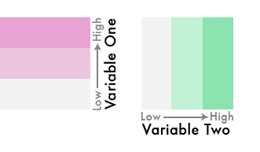

To match the 9 different colors with appropriate classes, we calculate 1/3-quantiles for both variables.

```r
# create 3 buckets for gini
quantiles_gini <- data %>%
                   pull(gini) %>%
                    quantile(probs = seq(0, 1, length.out = 4))

# create 3 buckets for mean income
quantiles_mean <- data %>%
                   pull(mean) %>%
                    quantile(probs = seq(0, 1, length.out = 4))

# create color scale that encodes two variables
# red for gini and blue for mean income
# the special notation with gather is due to readibility reasons
bivariate_color_scale <- tibble(
                                "3 - 3" = "#3F2949", # high inequality, high income
                                "2 - 3" = "#435786",
                                "1 - 3" = "#4885C1", # low inequality, high income
                                "3 - 2" = "#77324C",
                                "2 - 2" = "#806A8A", # medium inequality, medium income
                                "1 - 2" = "#89A1C8",
                                "3 - 1" = "#AE3A4E", # high inequality, low income
                                "2 - 1" = "#BC7C8F",
                                "1 - 1" = "#CABED0" # low inequality, low income
                               ) %>%
                                gather("group", "fill")
```

### Join Color Codes to the Data

Here the municipalities are put into the appropriate class corresponding to their average income and income (in-)equality.

```r
# cut into groups defined above and join fill
municipality_prod_geo %<>%
  mutate(gini_quantiles = cut(gini,
                            breaks = quantiles_gini,
                            include.lowest = TRUE),
         mean_quantiles = cut(mean,
                              breaks = quantiles_mean,
                              include.lowest = TRUE),
         # by pasting the factors together as numbers we match the groups defined
         # in the tibble bivariate_color_scale
         group = paste(as.numeric(gini_quantiles), "-", as.numeric(mean_quantiles))
         ) %>%
   # we now join the actual hex values per "group"
   # so each municipality knows its hex value based on the his gini and avg
   # income value
   left_join(bivariate_color_scale, by = "group")
```

### Draw the Map

As said above, this is basically the same approach as in the univariate case, except for the custom legend and annotations.

Adding the annotations is a bit cumbersome because the `curvature` and `nudge_*` arguments cannot be specified as data-driven aesthetics for `geom_curve()` and `geom_text()`, respectively. However, we need them to be data-driven, as we don’t want to specify the same curvature for all arrows, for example. For this reason we need to save all annotations into a separate data frame. We then call `geom_curve()` and `geom_text()` separately for each annotation to specify dynamic `curvature` and `nudge_*` arguments.

To find out from where to where an annotation arrow should be drawn, we looked at the [Swiss national map](https://map.geo.admin.ch) and manually extracted the x- and y- coordinates of the start and the end point of the arrow.

```r
annotations <- tibble(label = c("Grey areas mean\nlow income and\nlow inequality",
                                "Blue areas mean\nhigh income and\nlow inequality",
                                "Violet areas mean\nhigh income and\nhigh inequality",
                                "Red areas mean\nlow income and\nhigh inequality"),
                      arrow_from = c("548921,232972", # grey
                                     "771356,238335", # blue
                                     "781136,125067", # violet
                                     "616348,81869"), # red
                      arrow_to = c("622435,206784", # grey
                                   "712671,261998", # blue
                                   "786229,149597", # violet
                                   "602334,122674"), # red
                      curvature = c(0.2, # grey
                                    0.1, # blue
                                    -0.1, # violet
                                    -0.2), # red
                      nudge = c("-3000,0", # grey
                                "3000,5000", # blue
                                "0,-5000", # violet
                                "3000,0"), # red
                      just = c("1,0", # grey
                               "0,1", # blue
                               "0.5,1", # violet
                               "0,1") # red
                      ) %>%
                      separate(arrow_from, into = c("x", "y")) %>%
                      separate(arrow_to, into = c("xend", "yend")) %>%
                      separate(nudge, into = c("nudge_x", "nudge_y"), sep = "\\,") %>%
                      separate(just, into = c("hjust", "vjust"), sep = "\\,")
```

Now that the `annotations` data frame is ready, we can do the following:

```r
map <- ggplot(data = municipality_prod_geo # use the same dataset as before
             ) +
        # color municipalities according to their gini / income combination
        geom_sf(aes(fill = fill),
                color = "white", # use thin white stroke for municipalities
                size = 0.1) +
        # first: draw the relief
        geom_raster(data = relief,
                    aes(x = x,
                        y = y,
                        alpha = value)) +
        # use thicker white stroke for cantons
        geom_sf(data = canton_geo,
                fill = "transparent",
                color = "white",
                size = 0.5) +
         # draw lakes in light blue
        geom_sf(data = lake_geo,
                fill = "#D6F1FF",
                color = "transparent"
                ) +
        # use the "alpha hack" (as the "fill" aesthetic is already taken)
        scale_alpha(name = "",
                    range = c(0.6, 0),
                    guide = F) + # suppress legend
        # as the sf object municipality_prod_geo has a column with name "fill" that
        # contains the literal color as hex code for each municipality, we can use
        # scale_fill_identity here
        scale_fill_identity() +
        # add titles
        labs(x = NULL,
               y = NULL,
               title = "Switzerland's regional income (in-)equality",
               subtitle = paste0("Average yearly income and income",
                                 " (in-)equality in Swiss municipalities, 2015"),
               caption = default_caption) +
        # add the theme
        theme_map()

# add annotations one by one by walking over the annotations data frame
# this is necessary because we cannot define nudge_x, nudge_y and curvature
# in the aes in a data-driven way like as with x and y, for example
annotations %>%
  pwalk(function(...) {
    # collect all values in the row in a one-rowed data frame
    current <- tibble(...)

    # convert all columns from x to vjust to numeric
    # as pwalk apparently turns everything into a character (why???)
    current %<>%
      mutate_at(vars(x:vjust), as.numeric)

    # update the plot object with global assignment
    map <<- map +
             # for each annotation, add an arrow
             geom_curve(data = current,
                        aes(x = x,
                            xend = xend,
                            y = y,
                            yend = yend),
                        # that's the whole point of doing this loop:
                        curvature = current %>% pull(curvature),
                        size = 0.2,
                        arrow = arrow(length = unit(0.005, "npc"))
                        ) +
             # for each annotation, add a label
             geom_text(data = current,
                       aes(x = x,
                           y = y,
                           label = label,
                           hjust = hjust,
                           vjust = vjust),
                       # that's the whole point of doing this loop:
                       nudge_x = current %>% pull(nudge_x),
                       nudge_y = current %>% pull(nudge_y),
                       # other styles
                       family = default_font_family,
                       color = default_font_color,
                       size = 3)
  }
)
```

### Draw the Legend

For the legend we use the `geom_tile()` geometry of `ggplot2`. Before that, we have to quickly transform the `bivariate_color_scale` data frame, which contains all the hex values for all combinations of average income and income (in-)equality classes, so it has an x- and y-column that can be mapped to the respective aesthetics.

```r
# separate the groups
bivariate_color_scale %<>%
  separate(group, into = c("gini", "mean"), sep = " - ") %>%
   mutate(gini = as.integer(gini),
          mean = as.integer(mean))

legend <- ggplot() +
           geom_tile(data = bivariate_color_scale,
                     mapping = aes(x = gini,
                                   y = mean,
                                   fill = fill)) +
            scale_fill_identity() +
             theme_map() +
              # make font small enough
               theme(axis.title = element_text(size = 6)) +
                labs(x = "Higher inequality ⟶️",
                     y = "Higher income ⟶️") +
                 # quadratic tiles
                 coord_fixed()
```

### Combine Map and Legend

Here we just combine the legend with the map using the `cowplot` package. It allows us to specify the exact position of plots on the canvas, and scaling the width and height of plots (as we do with the legend). It would have been nice to rotate the legend by 45° but we didn’t find a way how to do this.

The numeric arguments to `draw_plot()` are basically trial and error.

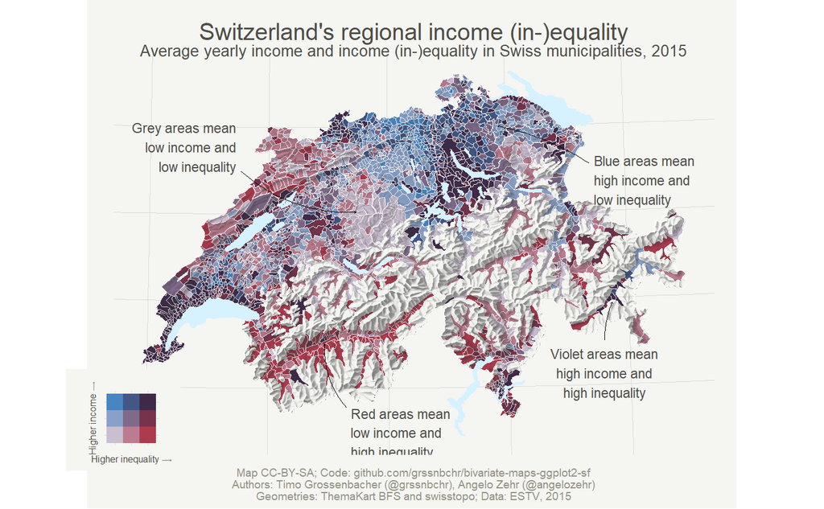

```r
ggdraw() +
 draw_plot(map, 0, 0, 1, 1) +
  draw_plot(legend, 0.05, 0.075, 0.2, 0.2)
```

That’s it! We hoped you liked this tutorial. If you have any questions or remarks, or know a better way of doing things, please let us know in the comment section.

You can also give us a shout on Twitter: We’re grssnbchr and angelozehr.

The code in this RMarkdown is linted with the [lintr package](https://github.com/jimhester/lintr), which is based on the [tidyverse style guide](http://style.tidyverse.org/).

```r
lintr::lint("index.Rmd")
```